# hse_hw

## Секция импортов

```python
import pandas as pd
import streamlit
import requests
import seaborn as sns
import matplotlib.pyplot as plt
from rich.console import Console
import json
import geopandas as gpd
from rich.table import Table
```

## Секция константных значений и объявлений

```python
data_path = "dataset/input/world-university-rankings/"
cwur_data = data_path + "cwur_data.csv"

geo_api_endpoint = "http://api.positionstack.com/v1/forward"

console = Console()
```

## Секция методов

```python
def uni_serialize():
    df = pd.read_csv(cwur_data)
    return df

def get_geolocation(uni_name):
    GEO_API_KEY = "7e5af99fd356a3a854e866c2f16064eb"
    try:
        target = list(json.loads(requests.get(url=geo_api_endpoint + f"?access_key={GEO_API_KEY}&query={uni_name}").text)["data"])[0]
        return {"latitude": target["latitude"], "longitude": target["longitude"]}
    except:
        return {"latitude" : None, "longitude" : None} # проверяем есть ли в принципе данные о геолокации


def add_geo(df):
    geo_lat = []
    geo_lon =[]
    if ("latitude" in df.columns.values or "longitude" in df.columns.values) : return # проверяем есть ли уже данные о геолокации, чтобы не считать их дважды
    for _ in df["institution"]:
        searched = get_geolocation(_)
        geo_lat.append(searched["latitude"])
        geo_lon.append(searched["longitude"])
    df.insert(3, "Latitude", geo_lat, True)
    df.insert(4, "Longitude", geo_lon, True)
    return df
```

# Основная часть

Проинициализируем данные, которые будем в дальнейшем обрабатывать

```python
uni_data = uni_serialize()
```

Получили базовую информацию об университетах из датасета. Добавим к этим данным их географическое положение через api [api.positionstack.com/v1](https://positionstack.com). Построим карту Америки и отметим на ней университеты, используя библиотеку geopandas. Я нашел в открытом доступе файлы с необходимыми для отображения карты Америки формами. [Источник](https://github.com/joncutrer/geopandas-tutorial/tree/master/data)

```python
# segment = uni_data.head()
# segment = add_geo(segment)
uni_data = add_geo(uni_data)
```

Источник геолокаций не гарантирует, что будет найден запрашиваемый университет. Следовательно, нам нужно проверить, какой процент из институтов не был найден, и выяснить, не повлияет ли это на дальнейший анализ

```python
geo_Latitude_NaN_count = uni_data.Latitude.isnull().sum()
geo_Longitude_NaN_count = uni_data.Longitude.isnull().sum()

table = Table()
table.add_column(header="latitude is Nan longitude is not NaN", style=" bold italic cyan")
table.add_column(header="longitude is NaN", style=" bold italic cyan")
table.add_row(str(geo_Latitude_NaN_count), str(geo_Longitude_NaN_count))
console.print(table)
console.print(f"both latitude and longitude is NaN\n{is_geo_both_NaN}")
console.print(f"[bold]No geolocation count:[/] {uni_data.Longitude.isnull().sum()}")
```

```
┏━━━━━━━━━━━━━━━━━━━━━━━━━━━━━━━━━━━━━━┳━━━━━━━━━━━━━━━━━━┓
┃ latitude is Nan longitude is not NaN ┃ longitude is NaN ┃
┡━━━━━━━━━━━━━━━━━━━━━━━━━━━━━━━━━━━━━━╇━━━━━━━━━━━━━━━━━━┩
│ 82                                   │ 82               │
└──────────────────────────────────────┴──────────────────┘
```

```
both latitude and longitude is NaN
0       True
1       True
2       True
3       True
4       True
        ...
2195    True
2196    True
2197    True
2198    True
2199    True
Name: Longitude, Length: 2200, dtype: bool
```

```
No geolocation count: 82
```

82 университета. Выглядит пугающе, но посмотрим, насколько это много в процентном соотношении:

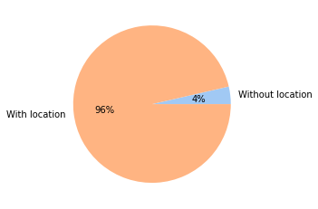

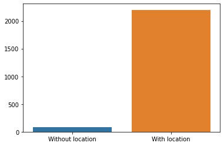

```python
pie_chart_labels = ["Without location", "With location"]
pie_data = [uni_data.Longitude.isnull().sum(), len(uni_data)]

colors = sns.color_palette('pastel')
plt.pie(x=pie_data, labels= pie_chart_labels, autopct='%.0f%%', colors=colors)
plt.show()
sns.barplot(x=pie_chart_labels, y=pie_data)
```

Как мы можем заметить, количество данных без геолокации находится в приделах разумного, что позволяет нам продолжить работать с этим датасетом.

```python
states = gpd.read_file("usa-states-census-2014.shp")
states.head()
```

|  | STATEFP | STATENS | AFFGEOID | GEOID | STUSPS | NAME | LSAD | ALAND | AWATER | region | geometry |
| --- | --- | --- | --- | --- | --- | --- | --- | --- | --- | --- | --- |
| 0 | 06 | 01779778 | 0400000US06 | 06 | CA | California | 00 | 403483823181 | 20483271881 | West | MULTIPOLYGON Z (((-118.59397 33.46720 0.00000,... |
| 1 | 11 | 01702382 | 0400000US11 | 11 | DC | District of Columbia | 00 | 158350578 | 18633500 | Northeast | POLYGON Z ((-77.11976 38.93434 0.00000, -77.04... |
| 2 | 12 | 00294478 | 0400000US12 | 12 | FL | Florida | 00 | 138903200855 | 31407883551 | Southeast | MULTIPOLYGON Z (((-81.81169 24.56874 0.00000, ... |
| 3 | 13 | 01705317 | 0400000US13 | 13 | GA | Georgia | 00 | 148963503399 | 4947080103 | Southeast | POLYGON Z ((-85.60516 34.98468 0.00000, -85.47... |
| 4 | 16 | 01779783 | 0400000US16 | 16 | ID | Idaho | 00 | 214045425549 | 2397728105 | West | POLYGON Z ((-117.24303 44.39097 0.00000, -117.... |

### Анализ востоочных и западных университетов США

Говорят, что вузы западного побережья круче Восточных. Проверим гиппотезу

```python
# штаты западного и восточного побережья
west = [states["STUSPS"][i] for i in range(len(states)) if 'est' in states["region"][i]]
east = [states["STUSPS"][i] for i in range(len(states)) if 'ast' in states["region"][i]]
```

тут я вспомнил, что нужно много строчек..

Посчитаем средний рейтинг вузов по США, разделив их на западные университеты и восточные:

```python
usa_uni = uni_data.loc[uni_data['country'] == 'USA', ["institution","Longitude", "Latitude", 'national_rank']]


west_uni_avg = usa_uni.loc[usa_uni['Longitude'] < -95]

east_uni_avg = usa_uni.loc[usa_uni['Longitude'] >= -95]
console.print(f"East coast average national rating: {east_uni_avg.national_rank.mean()}\nWest coast average national rating: {west_uni_avg.national_rank.mean()}\n")
```

```
East coast average national rating: 98.4175
West coast average national rating: 93.85798816568047
```

Данные цифры говорят нам о том, что средний рейтинг западных вузом все же выше, чем таковой у Восточных, пусть и незначительно. Отобразим данные на карте и посмотрим и проанализируем, почему так вышло:

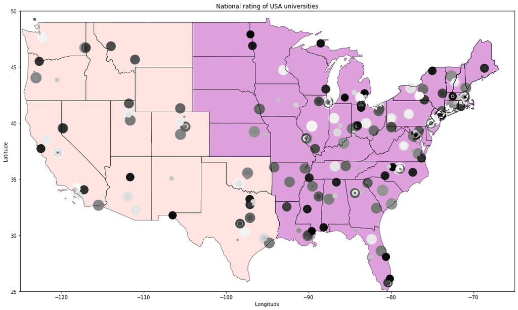

```python
west = states[states['region'] == 'West']
southwest = states[states['region'] == 'Southwest']
southeast = states[states['region'] == 'Southeast']
midwest = states[states['region'] == 'Midwest']
northeast = states[states['region'] == 'Northeast']
us_boundary_map = states.boundary.plot(figsize=(18, 12), color='Black', linewidth=.5)
west.plot(ax=us_boundary_map,  color="MistyRose")
southwest.plot(ax=us_boundary_map, color="MistyRose")
southeast.plot(ax=us_boundary_map, color="Plum")
midwest.plot(ax=us_boundary_map, color="Plum")
final_map = northeast.plot(ax=us_boundary_map, color="Plum")
plt.xlim(-125, -65)
plt.ylim(25, 50)
us_boundary_map.scatter(x=usa_uni["Longitude"], y=usa_uni["Latitude"],s=usa_uni["national_rank"][::-1]**(16/14),c=usa_uni["national_rank"], cmap="Greys"),

plt.title("National rating of USA universities")
plt.xlabel("Longitude")
plt.ylabel("Latitude")

plt.show()
```

На карте отчетливо видно, что, количество университетов на западе значительно ниже, чем на востоке, из чего можно сделать вывод, что количество менее престижных институтов оказывает сильное влияние на средний рейтинг, что и дает первенство западному побережью

### Поиск лучшего вуза

```python
quality_unis = uni_data[["institution","quality_of_education", "quality_of_faculty", "publications", "patents", "year"]]
console.print(f"size: {len(quality_unis)}")
quality_unis.head()
```

```
size: 2200
```

|  | institution | quality_of_education | quality_of_faculty | publications | patents | year |
| --- | --- | --- | --- | --- | --- | --- |
| 0 | Harvard University | 7 | 1 | 1 | 5 | 2012 |
| 1 | Massachusetts Institute of Technology | 9 | 3 | 12 | 1 | 2012 |
| 2 | Stanford University | 17 | 5 | 4 | 15 | 2012 |
| 3 | University of Cambridge | 10 | 4 | 16 | 50 | 2012 |
| 4 | California Institute of Technology | 2 | 7 | 37 | 18 | 2012 |

```python
fig = plt.figure(figsize=(100, 100))
gs = fig.add_gridspec(2,2, hspace=0, wspace=0)
(ax1, ax2), (ax3, ax4) = gs.subplots(sharex='col', sharey='row')
sns.set()
fig.suptitle('Оценка достижений вузов')
ax1.set_xlabel('institution')
ax1.tick_params(
    bottom = True,
    top = True,
    # labelbottom = True,
    labeltop = True,
    direction = 'inout',
    labelrotation = 45
)
quality_unis.sort_values(["quality_of_education", "year"])
quality_unis.drop_duplicates(keep="last")
quality_unis = quality_unis.head(100)
sns.barplot(x=quality_unis['institution'], y=quality_unis["quality_of_education"], ax=ax1)

ax2.tick_params(
    bottom = True,
    top = True,
    labelbottom = True,
    labeltop = True,
    direction = 'inout',
    labelrotation = 45
)
ax2.set_xlabel('institution')
quality_unis.sort_values(["quality_of_faculty", "year"])
quality_unis.drop_duplicates(keep="last")
quality_unis = quality_unis.head(100)
sns.barplot(x=quality_unis['institution'], y=quality_unis["quality_of_faculty"], ax=ax2)

ax3.tick_params(
    bottom = True,
    top = True,
    # labelbottom = True,
    labeltop = True,
    direction = 'inout',
    labelrotation = 45
)
ax3.set_xlabel('institution')
quality_unis.sort_values(["publications", "year"])
quality_unis.drop_duplicates(keep="last")
quality_unis = quality_unis.head(100)
sns.barplot(x=quality_unis['institution'], y=quality_unis["publications"], ax=ax3)

ax4.tick_params(
    bottom = True,
    # top = True,
    labelbottom = True,
    # labeltop = True,
    direction = 'inout',
    labelrotation = 45
)
ax4.set_xlabel('institution')
quality_unis.sort_values(["patents", "year"])
quality_unis.drop_duplicates(keep="last")
quality_unis = quality_unis.head(100)
sns.barplot(x=quality_unis['institution'], y=quality_unis["publications"], ax=ax4)
```

[figure not shown]

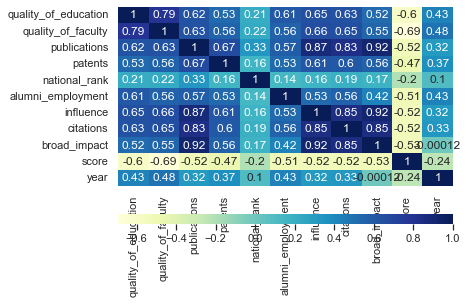

```python
quality_unis = uni_data[["institution","quality_of_education", "quality_of_faculty", "publications", "patents", "country", "national_rank", "alumni_employment", "influence", "citations", "broad_impact", "score", "year"]]
figure = plt.figure(figsize=(12, 12))
grid_kws = {"height_ratios": (.9, .05), "hspace": .3}
f, (ax, cbar_ax) = plt.subplots(2, gridspec_kw=grid_kws)
sns.heatmap(data=quality_unis.corr(), cmap="YlGnBu", annot=True, cbar_ax=cbar_ax,
                 cbar_kws={"orientation": "horizontal"}, ax=ax)
```